# Part I - Loan Data from Prosper

## Introduction

This dataset details data regarding various variables related to loans from the identification details of the borrowers to the various loan amounts, the status of the loan, borrower rate and other related characteristics.

## Preliminary Wrangling

```python
# import all packages and set plots to be embedded inline
import numpy as np
import pandas as pd
import matplotlib.pyplot as plt
import seaborn as sb

%matplotlib inline
```

```python
# load dataset into a pandas dataframe
df = pd.read_csv('prosperLoanData.csv')
loandata_copy = df.copy()
df.head(10)
```

|  | ListingKey | ListingNumber | ListingCreationDate | CreditGrade | Term | LoanStatus | ClosedDate | BorrowerAPR | BorrowerRate | LenderYield | ... | LP_ServiceFees | LP_CollectionFees | LP_GrossPrincipalLoss | LP_NetPrincipalLoss | LP_NonPrincipalRecoverypayments | PercentFunded | Recommendations | InvestmentFromFriendsCount | InvestmentFromFriendsAmount | Investors |
| --- | --- | --- | --- | --- | --- | --- | --- | --- | --- | --- | --- | --- | --- | --- | --- | --- | --- | --- | --- | --- | --- |
| 0 | 1021339766868145413AB3B | 193129 | 2007-08-26 19:09:29.263000000 | C | 36 | Completed | 2009-08-14 00:00:00 | 0.16516 | 0.1580 | 0.1380 | ... | -133.18 | 0.0 | 0.0 | 0.0 | 0.0 | 1.0 | 0 | 0 | 0.0 | 258 |
| 1 | 10273602499503308B223C1 | 1209647 | 2014-02-27 08:28:07.900000000 | NaN | 36 | Current | NaN | 0.12016 | 0.0920 | 0.0820 | ... | 0.00 | 0.0 | 0.0 | 0.0 | 0.0 | 1.0 | 0 | 0 | 0.0 | 1 |
| 2 | 0EE9337825851032864889A | 81716 | 2007-01-05 15:00:47.090000000 | HR | 36 | Completed | 2009-12-17 00:00:00 | 0.28269 | 0.2750 | 0.2400 | ... | -24.20 | 0.0 | 0.0 | 0.0 | 0.0 | 1.0 | 0 | 0 | 0.0 | 41 |
| 3 | 0EF5356002482715299901A | 658116 | 2012-10-22 11:02:35.010000000 | NaN | 36 | Current | NaN | 0.12528 | 0.0974 | 0.0874 | ... | -108.01 | 0.0 | 0.0 | 0.0 | 0.0 | 1.0 | 0 | 0 | 0.0 | 158 |
| 4 | 0F023589499656230C5E3E2 | 909464 | 2013-09-14 18:38:39.097000000 | NaN | 36 | Current | NaN | 0.24614 | 0.2085 | 0.1985 | ... | -60.27 | 0.0 | 0.0 | 0.0 | 0.0 | 1.0 | 0 | 0 | 0.0 | 20 |
| 5 | 0F05359734824199381F61D | 1074836 | 2013-12-14 08:26:37.093000000 | NaN | 60 | Current | NaN | 0.15425 | 0.1314 | 0.1214 | ... | -25.33 | 0.0 | 0.0 | 0.0 | 0.0 | 1.0 | 0 | 0 | 0.0 | 1 |
| 6 | 0F0A3576754255009D63151 | 750899 | 2013-04-12 09:52:56.147000000 | NaN | 36 | Current | NaN | 0.31032 | 0.2712 | 0.2612 | ... | -22.95 | 0.0 | 0.0 | 0.0 | 0.0 | 1.0 | 0 | 0 | 0.0 | 1 |
| 7 | 0F1035772717087366F9EA7 | 768193 | 2013-05-05 06:49:27.493000000 | NaN | 36 | Current | NaN | 0.23939 | 0.2019 | 0.1919 | ... | -69.21 | 0.0 | 0.0 | 0.0 | 0.0 | 1.0 | 0 | 0 | 0.0 | 1 |
| 8 | 0F043596202561788EA13D5 | 1023355 | 2013-12-02 10:43:39.117000000 | NaN | 36 | Current | NaN | 0.07620 | 0.0629 | 0.0529 | ... | -16.77 | 0.0 | 0.0 | 0.0 | 0.0 | 1.0 | 0 | 0 | 0.0 | 1 |
| 9 | 0F043596202561788EA13D5 | 1023355 | 2013-12-02 10:43:39.117000000 | NaN | 36 | Current | NaN | 0.07620 | 0.0629 | 0.0529 | ... | -16.77 | 0.0 | 0.0 | 0.0 | 0.0 | 1.0 | 0 | 0 | 0.0 | 1 |

10 rows × 81 columns

```python
df.shape
```

```
(113937, 81)
```

```python
df.info()
```

```
<class 'pandas.core.frame.DataFrame'>
RangeIndex: 113937 entries, 0 to 113936
Data columns (total 81 columns):
 #   Column                               Non-Null Count   Dtype
---  ------                               --------------   -----
 0   ListingKey                           113937 non-null  object
 1   ListingNumber                        113937 non-null  int64
 2   ListingCreationDate                  113937 non-null  object
 3   CreditGrade                          28953 non-null   object
 4   Term                                 113937 non-null  int64
 5   LoanStatus                           113937 non-null  object
 6   ClosedDate                           55089 non-null   object
 7   BorrowerAPR                          113912 non-null  float64
 8   BorrowerRate                         113937 non-null  float64
 9   LenderYield                          113937 non-null  float64
```

[output cut: 73 more lines]

```python
# select the columns needed using the numpy array excluding those with numerous missing values

df = df.iloc[:, np.r_[1:10, 16:23, 31:33, 46:50, 63:68, 80:81]]
df.head()
```

|  | ListingNumber | ListingCreationDate | CreditGrade | Term | LoanStatus | ClosedDate | BorrowerAPR | BorrowerRate | LenderYield | ListingCategory (numeric) | ... | DebtToIncomeRatio | IncomeRange | IncomeVerifiable | StatedMonthlyIncome | LoanOriginalAmount | LoanOriginationDate | LoanOriginationQuarter | MemberKey | MonthlyLoanPayment | Investors |
| --- | --- | --- | --- | --- | --- | --- | --- | --- | --- | --- | --- | --- | --- | --- | --- | --- | --- | --- | --- | --- | --- |
| 0 | 193129 | 2007-08-26 19:09:29.263000000 | C | 36 | Completed | 2009-08-14 00:00:00 | 0.16516 | 0.1580 | 0.1380 | 0 | ... | 0.17 | $25,000-49,999 | True | 3083.333333 | 9425 | 2007-09-12 00:00:00 | Q3 2007 | 1F3E3376408759268057EDA | 330.43 | 258 |
| 1 | 1209647 | 2014-02-27 08:28:07.900000000 | NaN | 36 | Current | NaN | 0.12016 | 0.0920 | 0.0820 | 2 | ... | 0.18 | $50,000-74,999 | True | 6125.000000 | 10000 | 2014-03-03 00:00:00 | Q1 2014 | 1D13370546739025387B2F4 | 318.93 | 1 |
| 2 | 81716 | 2007-01-05 15:00:47.090000000 | HR | 36 | Completed | 2009-12-17 00:00:00 | 0.28269 | 0.2750 | 0.2400 | 0 | ... | 0.06 | Not displayed | True | 2083.333333 | 3001 | 2007-01-17 00:00:00 | Q1 2007 | 5F7033715035555618FA612 | 123.32 | 41 |
| 3 | 658116 | 2012-10-22 11:02:35.010000000 | NaN | 36 | Current | NaN | 0.12528 | 0.0974 | 0.0874 | 16 | ... | 0.15 | $25,000-49,999 | True | 2875.000000 | 10000 | 2012-11-01 00:00:00 | Q4 2012 | 9ADE356069835475068C6D2 | 321.45 | 158 |
| 4 | 909464 | 2013-09-14 18:38:39.097000000 | NaN | 36 | Current | NaN | 0.24614 | 0.2085 | 0.1985 | 2 | ... | 0.26 | $100,000+ | True | 9583.333333 | 15000 | 2013-09-20 00:00:00 | Q3 2013 | 36CE356043264555721F06C | 563.97 | 20 |

5 rows × 28 columns

```python
# Drop the columns not needed to have a more compact dataset

df.drop(['ListingCreationDate', 'CreditGrade', 'ClosedDate', 'LoanOriginationDate', 'MemberKey'], axis = 1, inplace = True)
df.sample(5)
```

|  | ListingNumber | Term | LoanStatus | BorrowerAPR | BorrowerRate | LenderYield | ListingCategory (numeric) | BorrowerState | Occupation | EmploymentStatus | ... | OpenRevolvingAccounts | OpenRevolvingMonthlyPayment | DebtToIncomeRatio | IncomeRange | IncomeVerifiable | StatedMonthlyIncome | LoanOriginalAmount | LoanOriginationQuarter | MonthlyLoanPayment | Investors |
| --- | --- | --- | --- | --- | --- | --- | --- | --- | --- | --- | --- | --- | --- | --- | --- | --- | --- | --- | --- | --- | --- |
| 67513 | 92556 | 36 | Completed | 0.08433 | 0.0775 | 0.0650 | 0 | CA | Other | Not available | ... | 12 | 66.0 | 0.04 | Not displayed | True | 4166.666667 | 3000 | Q1 2007 | 93.66 | 83 |
| 35500 | 140505 | 36 | Defaulted | 0.23748 | 0.2300 | 0.2200 | 0 | CA | Other | Full-time | ... | 8 | 457.0 | 0.43 | $25,000-49,999 | True | 2653.333333 | 5000 | Q2 2007 | 193.55 | 53 |
| 36614 | 543888 | 36 | Completed | 0.28974 | 0.2511 | 0.2411 | 1 | CA | Other | Employed | ... | 3 | 421.0 | 0.43 | $25,000-49,999 | True | 2916.666667 | 10000 | Q4 2011 | 398.18 | 198 |
| 14081 | 612447 | 60 | Current | 0.17849 | 0.1551 | 0.1451 | 1 | AZ | Other | Employed | ... | 3 | 272.0 | 0.20 | $25,000-49,999 | True | 2500.000000 | 9000 | Q3 2012 | 216.53 | 180 |
| 66502 | 603237 | 36 | Current | 0.12427 | 0.0964 | 0.0864 | 1 | NC | Professional | Employed | ... | 14 | 1203.0 | 0.27 | $100,000+ | True | 8333.333333 | 14000 | Q3 2012 | 449.38 | 241 |

5 rows × 23 columns

```python
print(df.shape)

df.info()
```

```
(113937, 23)
<class 'pandas.core.frame.DataFrame'>
RangeIndex: 113937 entries, 0 to 113936
Data columns (total 23 columns):
 #   Column                       Non-Null Count   Dtype
---  ------                       --------------   -----
 0   ListingNumber                113937 non-null  int64
 1   Term                         113937 non-null  int64
 2   LoanStatus                   113937 non-null  object
 3   BorrowerAPR                  113912 non-null  float64
 4   BorrowerRate                 113937 non-null  float64
 5   LenderYield                  113937 non-null  float64
 6   ListingCategory (numeric)    113937 non-null  int64
 7   BorrowerState                108422 non-null  object
 8   Occupation                   110349 non-null  object
```

[output cut: 16 more lines]

```python
df.describe()
```

|  | ListingNumber | Term | BorrowerAPR | BorrowerRate | LenderYield | ListingCategory (numeric) | EmploymentStatusDuration | OpenRevolvingAccounts | OpenRevolvingMonthlyPayment | DebtToIncomeRatio | StatedMonthlyIncome | LoanOriginalAmount | MonthlyLoanPayment | Investors |
| --- | --- | --- | --- | --- | --- | --- | --- | --- | --- | --- | --- | --- | --- | --- |
| count | 1.139370e+05 | 113937.000000 | 113912.000000 | 113937.000000 | 113937.000000 | 113937.000000 | 106312.000000 | 113937.00000 | 113937.000000 | 105383.000000 | 1.139370e+05 | 113937.00000 | 113937.000000 | 113937.000000 |
| mean | 6.278857e+05 | 40.830248 | 0.218828 | 0.192764 | 0.182701 | 2.774209 | 96.071582 | 6.96979 | 398.292161 | 0.275947 | 5.608026e+03 | 8337.01385 | 272.475783 | 80.475228 |
| std | 3.280762e+05 | 10.436212 | 0.080364 | 0.074818 | 0.074516 | 3.996797 | 94.480605 | 4.63097 | 447.159711 | 0.551759 | 7.478497e+03 | 6245.80058 | 192.697812 | 103.239020 |
| min | 4.000000e+00 | 12.000000 | 0.006530 | 0.000000 | -0.010000 | 0.000000 | 0.000000 | 0.00000 | 0.000000 | 0.000000 | 0.000000e+00 | 1000.00000 | 0.000000 | 1.000000 |
| 25% | 4.009190e+05 | 36.000000 | 0.156290 | 0.134000 | 0.124200 | 1.000000 | 26.000000 | 4.00000 | 114.000000 | 0.140000 | 3.200333e+03 | 4000.00000 | 131.620000 | 2.000000 |
| 50% | 6.005540e+05 | 36.000000 | 0.209760 | 0.184000 | 0.173000 | 1.000000 | 67.000000 | 6.00000 | 271.000000 | 0.220000 | 4.666667e+03 | 6500.00000 | 217.740000 | 44.000000 |
| 75% | 8.926340e+05 | 36.000000 | 0.283810 | 0.250000 | 0.240000 | 3.000000 | 137.000000 | 9.00000 | 525.000000 | 0.320000 | 6.825000e+03 | 12000.00000 | 371.580000 | 115.000000 |
| max | 1.255725e+06 | 60.000000 | 0.512290 | 0.497500 | 0.492500 | 20.000000 | 755.000000 | 51.00000 | 14985.000000 | 10.010000 | 1.750003e+06 | 35000.00000 | 2251.510000 | 1189.000000 |

### What is the structure of your dataset?

The original dataset had 113,937 loan observations spread across 81 variables. Most of them were numeric in nature with some like the ListingCategory listed from a scale of 0 to 20 to represent its string observation of reasons listed for applying for loans.

However, I performed some transformation on the expansive column variables by selecting the key columns I think will be of great importance for our analysis which truncated the dataset to 23 columns.

### What is/are the main feature(s) of interest in your dataset?

The main features of interest in the dataset are the factors affecting the outcome of a loan especially the amount of money issued for the loan and its monthly payment for a prospective and/or current borrower.

### What features in the dataset do you think will help support your investigation into your feature(s) of interest?

I deduce of importance in this dataset are the quantitative variables such as the BorrowerRate, LoanOriginalAmount, MonthlyLoanPayment with those having higher loans remit higher monthly fees. Qualitative ones such as the employment status also influences the outcome as those that are in stable employment or self employed are more likely to take higher loans.

## Univariate Exploration

I will start by looking at the key variables of interest with regards to loan, the BorrowerRate or the Interest rate.

#### How does the interest rate charged on a loan and expected lender yield for investors appear?

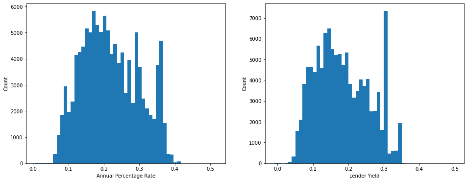

```python
# standard scaled plot
fig, ax = plt.subplots(ncols=2, figsize = [16, 6])

variables = ['BorrowerAPR', 'LenderYield']
for i in range(len(variables)):
    var = variables[i]
    bins = np.arange(min(df[var]), max(df[var])+0.01, 0.01)
    ax[i].hist(data = df, x = var, bins = bins)
    ax[0].set_xlabel('Annual Percentage Rate')
    ax[1].set_xlabel('Lender Yield')
    ax[0].set_ylabel('Count')
    ax[1].set_ylabel('Count')

plt.show()
```

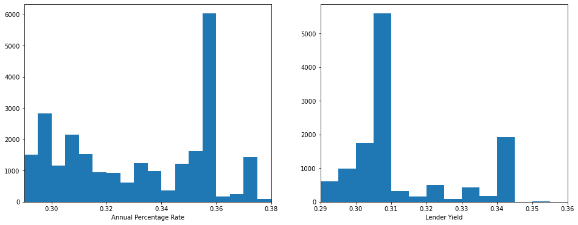

```python
# highlight the highest peaks to the right-most part through evaluating through limits with smaller bin sizes

plt.figure(figsize=[16, 6])

bins = np.arange(0, df.BorrowerAPR.max()+0.005, 0.005)

plt.subplot(1, 2, 1)
plt.hist(data=df, x='BorrowerAPR', bins=bins)
plt.xlim([0.29, 0.38])
plt.xlabel('Annual Percentage Rate')

bins = np.arange(0, df.LenderYield.max()+0.005, 0.005)

plt.subplot(1, 2, 2)
plt.hist(data=df, x='LenderYield', bins=bins)
plt.xlim([0.29, 0.36])
plt.xlabel('Lender Yield');
```

The Annual percentage rates charged on loans seems to have a have a very strong similar relationship with the expected annual yield that lenders can expect from their investment.

However, on closer analysis of its peaks we see that borrowers pay a higher interest(0.36) and eventual total cost of credit for their loans than inveestors receive for their investment(0.31). This can create a margin for Prosper to profit from.

Now, let's examine some categoric variables that influence how a loan is disbursed.

#### What are key lisitings selected by borrowers for applying for loans?

```python
# replaced the numeric values with the string values
df['ListingCategory'] = df['ListingCategory (numeric)'].map({0:'Not Available', 1:'Debt Consolidation', 2:'Home Improvement', 3:'Business', 4:'Personal Loan', 5:'Student Use', 6:'Auto', 7:'Other', 8:'Baby&Adoption', 9:'Boat', 10:'Cosmetic Procedure', 11:'Engagement Ring', 12:'Green Loans', 13:'Household Expenses', 14:'Large Purchases', 15:'Medical/Dental', 16:'Motorcycle', 17:'RV', 18:'Taxes', 19:'Vacation', 20:'Wedding Loans'})

listingC = df.ListingCategory.value_counts().sort_index(ascending=True)
```

```python
def barChart(Dataframe, x_label, y_label, title, size):
    '''Define quick function to plot a bar chart'''
    Dataframe.plot.barh(figsize=size)
    plt.xlabel(x_label, fontsize = 13)
    plt.ylabel(y_label, fontsize = 13)
    plt.title(title, fontsize = 13)
    plt.show()
```

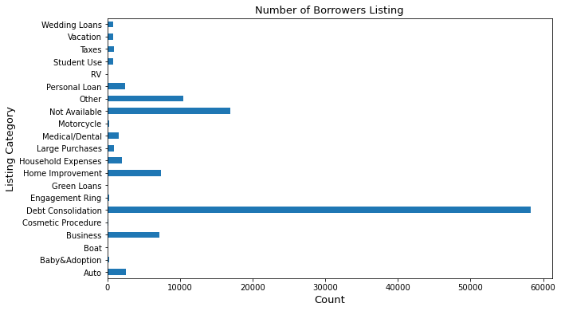

```python
barChart(listingC, 'Count', 'Listing Category', 'Number of Borrowers Listing', (10, 6))
```

```python
# further analysis to get the top reasons borrowers take out loans

df['ListingCategory'].value_counts().mean()
```

```
5425.571428571428
```

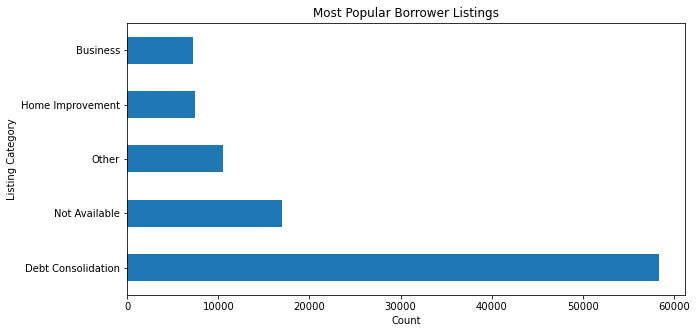

```python
# Filter the most popular which are those above average
# In python, a `lambda` function is an anonymous function that can have only one expression.
listing = df.groupby('ListingCategory').filter(lambda x: len(x) > 5000)

listing['ListingCategory'].value_counts().plot(kind = 'barh', figsize=(10, 5))

plt.xlabel('Count')
plt.ylabel('Listing Category')
plt.title('Most Popular Borrower Listings');
```

The majority of borrowers appear to apply for loans in a bid to refinance their other higher consumer debt which might be lapsing. Although some borrowers do not list their reasons, home improvements and business ventures also take precedence among reasons borrowers get loans.

#### What is the status of the borrowers in relation to their occupation?

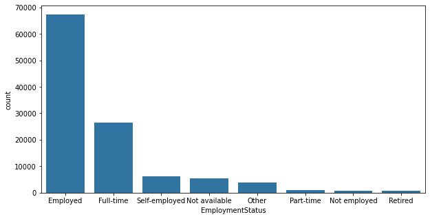

```python
plt.figure(figsize=[10, 5])
color = sb.color_palette()[0]

sb.countplot(data=df, x='EmploymentStatus', color=color, order=df['EmploymentStatus'].value_counts().index);
```

In addition to consolidating debt, identifying as an employed person improves the probability of getting a loan as earlier hypothesized. Being employed full-time also increases the likelihood of getting a loan.

#### How does the original amount of the loan and its monthly payment appear?

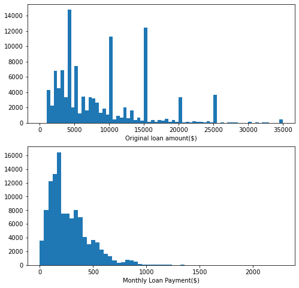

```python
# plot the loan and its installment side by side
plt.figure(figsize=[8, 8])
binsl = np.arange(0, df.LoanOriginalAmount.max()+500, 500)

plt.subplot(2, 1, 1)
plt.hist(data=df, x='LoanOriginalAmount', bins=binsl)
plt.xlabel('Original loan amount($)')


binsm = np.arange(0, df.MonthlyLoanPayment.max()+40, 40)

plt.subplot(2, 1, 2)
plt.hist(data=df, x='MonthlyLoanPayment', bins=binsm)
plt.xlabel('Monthly Loan Payment($)')
plt.show()
```

```python
np.log10(df.LoanOriginalAmount.min())
```

```
3.0
```

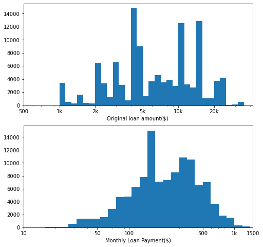

```python
# since there's a long-tail distribution with skew to the right a log transformation will do
plt.figure(figsize=[8, 8])

log_binsize = 0.05
binsl = 10 ** np.arange(3.0, np.log10(df['LoanOriginalAmount'].max())+log_binsize, log_binsize)

plt.subplot(2, 1, 1)
plt.hist(data=df, x='LoanOriginalAmount', bins=binsl)
plt.xscale('log')
plt.xticks([500, 1e3, 2e3, 5e3, 1e4, 2e4], [500, '1k', '2k', '5k', '10k', '20k'])
plt.xlabel('Original loan amount($) ')

binsm = 10 ** np.arange(0, np.log10(df['MonthlyLoanPayment'].max())+0.075, 0.075)

plt.subplot(2, 1, 2)
plt.hist(data=df, x='MonthlyLoanPayment', bins=binsm)
plt.xscale('log')
plt.xlim(10, 1500)
plt.xticks([10, 50, 100, 500, 1000, 1500], [10, 50, 100, 500, '1k', 1500])
plt.xlabel('Monthly Loan Payment($)')

plt.show()
```

The scheduled monthly loan payments has a long-tailed distribution with positive-skewness. Most of the payments are on the lower priced end. When plotted on the log-scale, it appears unimodal with majority of the payments ranging between 100 and 800.

Further investigation of this key variable will be seen in relation to other key metrics.

### Discuss the distribution(s) of your variable(s) of interest. Were there any unusual points? Did you need to perform any transformations?

The monthly loan payments took a biased range values towards the right which necessitated a log transformation that made it look fairly unimodal.

### Of the features you investigated, were there any unusual distributions? Did you perform any operations on the data to tidy, adjust, or change the form of the data? If so, why did you do this?

When investigating the listing categories, I had to transform the numeric values to string values for better interpretation. To improve the clarity of analysis I filtered those above the mean value count to view top 5 categories.

## Bivariate Exploration

To start off with, I want to look at the pairwise correlations present between features in the data.

#### How does BorrowerAPR, BorrowerRate, LenderYield, LoanOriginalAmount, MonthlyLoanPayment relate pairwise?

```python
numeric_vars = ['BorrowerAPR', 'BorrowerRate', 'LenderYield', 'LoanOriginalAmount', 'MonthlyLoanPayment']
```

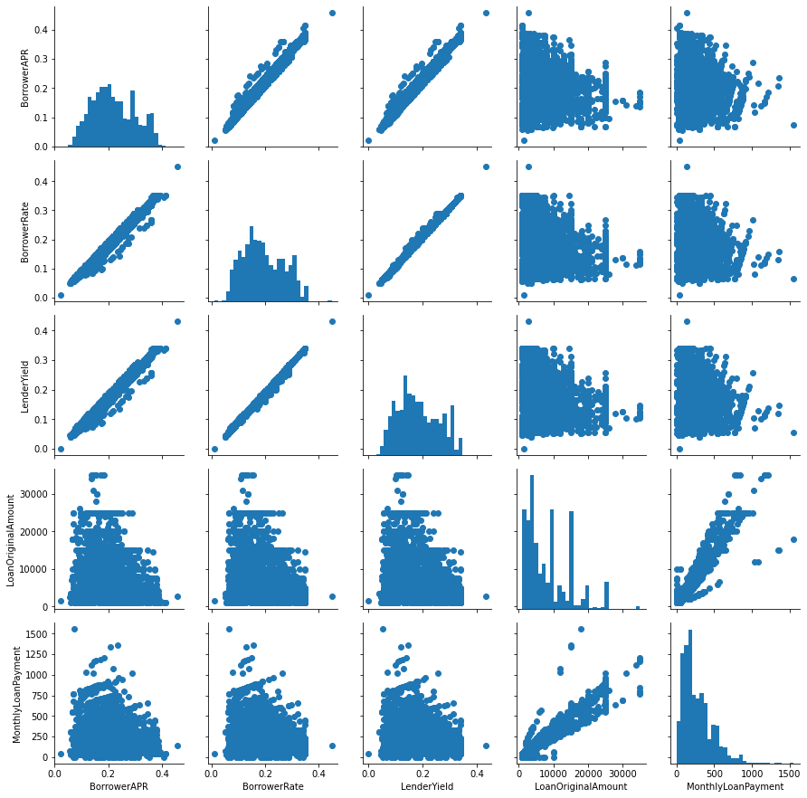

```python
# plot matrix: sample 3000 loans so that plots are clearer and they render faster
loan_sample = df.sample(n = 3000, replace = False)

g = sb.PairGrid(data=loan_sample, vars = numeric_vars)
g.map_diag(plt.hist, bins = 30)
g.map_offdiag(plt.scatter);
```

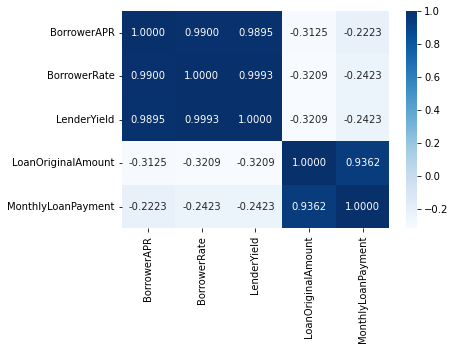

```python
sb.heatmap(loan_sample[numeric_vars].corr(), cmap = 'Blues', annot =True, fmt = '.4f');
```

As expected, the BorrowerRate, BorrowerAPR and LenderYield dimensions are all highly correlated with one another. This is a good indication of favorable terms of taking loans as there are minor differences in the rates charged particularly between the interests rate and APR. This means there is little additional fees and time charged over the life of the loans compared to the interest rate. The inverse relation to LoanOriginalAmount and MonthlyLoanPayment is a moderate negative correlation.

LoanOriginalAmount and MonthlyLoanPayment has strong positive correlation as previously hypotheisized. This is to be expected as huge loan amounts requirelarger portions of money to financeon a monthly basis. As confirming the hypothesis, they'll be of key importance for the subsequent analyses.

Next is to look at how they correlate with various categorical variables.

#### How has the loan amount progressed over the years?

```python
# The Series.apply() method invokes the `lambda` function on each value of the column.

df['Year'] = df['LoanOriginationQuarter'].apply(lambda x:x.split()[1])
```

```python
# Define chart to plot line chart

def chart(Dataframe, x_values, x_label, y_values, y_label, colour):
    '''quick function to compute the average loan disbursed for over time in a line plot'''
    Dataframe.plot(x=x_values, y=y_values, color=colour, figsize=(10,6), grid=True)
    plt.xlabel(x_label, fontsize = 13)
    plt.ylabel(y_label, fontsize = 13)
    plt.show();
```

```python
df_loans = df.groupby('Year')['LoanOriginalAmount'].mean()
```

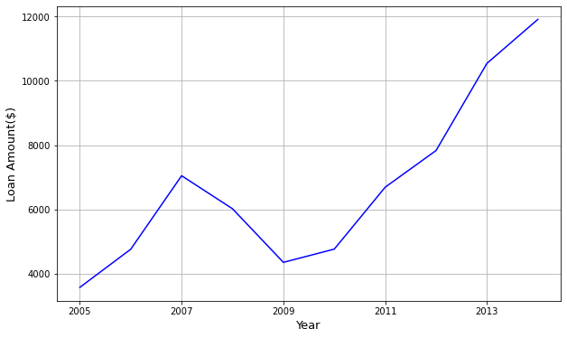

```python
chart(df_loans, 'Year', 'Year', 'LoanOriginalAmount', 'Loan Amount($)', 'blue')
```

From the trend observed above, Prosper progressively increased the amount of money disbursed for its loan particlarly from the year 2009. This can be due to more thorough record keeping being done for loans post July 2009 to include variables like EstimatedEffectiveYield. This is not of utter importance for the analysis.

#### How does the average loan amount differ across different employment statuses?

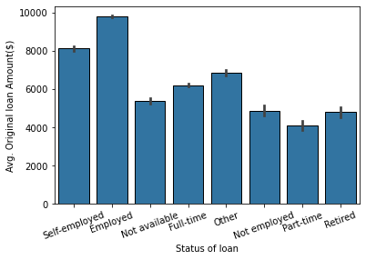

```python
sb.barplot(data=df, x='EmploymentStatus', y='LoanOriginalAmount', color=color, edgecolor='black')

plt.xticks(rotation=20)
plt.xlabel('Status of loan')
plt.ylabel('Avg. Original loan Amount($)');
```

#### How well do the loans disbursed perform as per their lisitng categories?

```python
def plot_count(data, col, hue, order):
    '''Quick function to call out the xvalues and other parameters to plot a countplot graph'''
    plt.figure(figsize=[10, 5])
    sb.countplot(x=col, hue=hue, data=df, order=order, edgecolor='black')
    plt.legend(loc = 6, bbox_to_anchor = (1.0, 0.5)) # legend to right of figure
    plt.show()
```

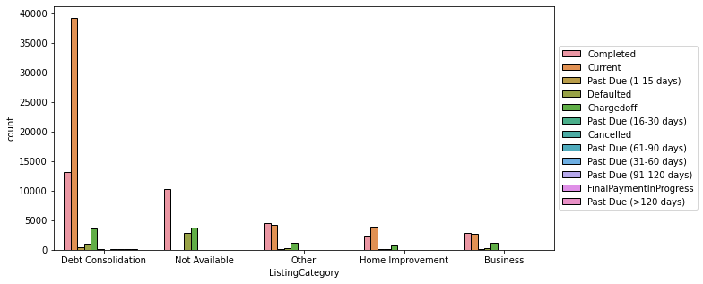

```python
plot_count(df, 'ListingCategory', 'LoanStatus', listing['ListingCategory'].value_counts().index)
```

This will lead us to explore further the lender yield against the number of investors funding a loan.

#### Does more investors funding a loan translate to higher loan amounts and yields received from their investment?

[figure not shown]

```python
# plot a sample of the dataset with a regression line to get perspective of interrelation
sb.regplot(data=loan_sample, x='Investors', y='LoanOriginalAmount', scatter_kws={'alpha' : 0.3})

plt.xlabel('Lender Yield')
plt.ylabel('Number of Investors');
```

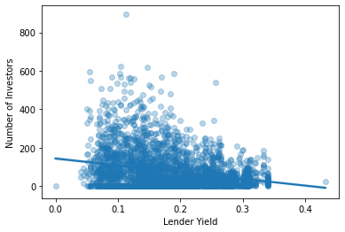

```python
sb.regplot(data=loan_sample, x='LenderYield', y='Investors', scatter_kws={'alpha' : 0.3})

plt.xlabel('Lender Yield')
plt.ylabel('Number of Investors');
```

As expected, the more the number of investors funding a loan, the higher the loan is as observed from the strong positive correlation.

It's interesting to note a moderate negative correlation for the lender yield investors can expect from their investment annually against the number of investors. This means more investors funding a loan does not necessarily translate to higher returns when interest rates and fees are compounded annually.

It will be exciting to see how these variables come together in the subsequent analysis.

### Talk about some of the relationships you observed in this part of the investigation. How did the feature(s) of interest vary with other features in the dataset?

Using a random sample of the loans from the dataset, it was evident that key original loan amounts and the monthly loan amounts had a strong linear relationship as hypothesized. This will further be explored in the next section.

Although an increase in amount of loans disbursed over years after 2009 was observed, there are comprehensive records kept for those years to include other variables like the Prosper Rating which we dropped and hence which slightly biases the data. Thus, it is good just for our knowledge and not analysis.

### Did you observe any interesting relationships between the other features (not the main feature(s) of interest)?

It was surprising to see that the lender yield and investors that funded the loan were not strongly positively corelated as expected. One expected that the more the number of investors funding a loan, the higher the investment outcomes which was not observed. This might result from other underlying factors in the institution that affects the structure and outcome of the loan.

## Multivariate Exploration

The main thing I want to explore in this part is how the categorical variables play a role in how the amount of loan issued and the scheduled monthly payments remitted towards paying off the loan.

#### How does the key loan amounts and its scheduled monthly payments differ across LoanStatus, EmploymentStatus and the Term taken to pay off the loan?

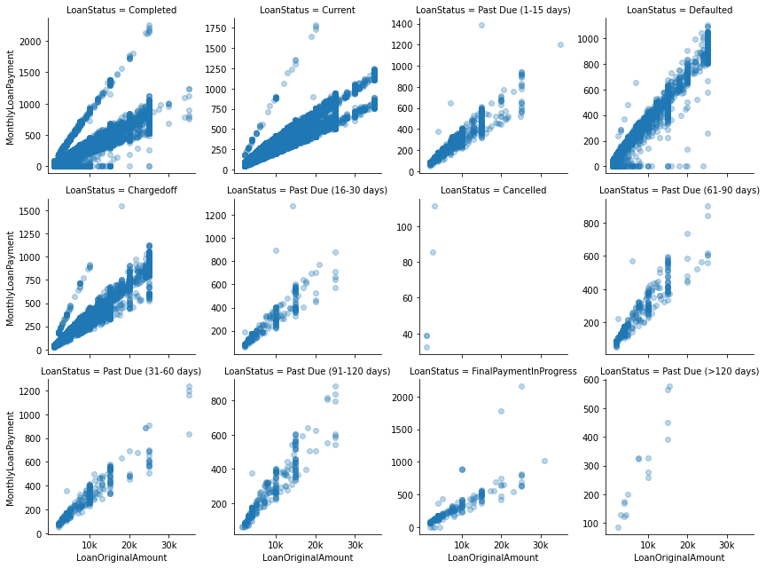

```python
# create faceted scatter plots on levels of the Loan Status variable
g = sb.FacetGrid(data=df, col='LoanStatus', col_wrap = 4, height = 3, sharey=False)
g.map(plt.scatter, 'LoanOriginalAmount', 'MonthlyLoanPayment', alpha=0.3)

plt.xticks([10000, 20000, 30000], ['10k', '20k', '30k'])
plt.show()
```

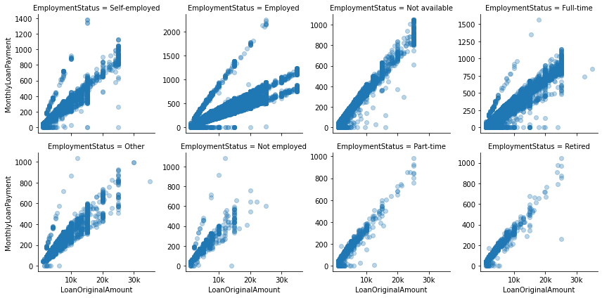

```python
# create faceted scatter plots on levels of the Employment Status variable
g = sb.FacetGrid(data=df, col='EmploymentStatus', col_wrap = 4, height = 3, sharey=False)
g.map(plt.scatter, 'LoanOriginalAmount', 'MonthlyLoanPayment', alpha=0.3)

plt.xticks([10000, 20000, 30000], ['10k', '20k', '30k'])
plt.show()
```

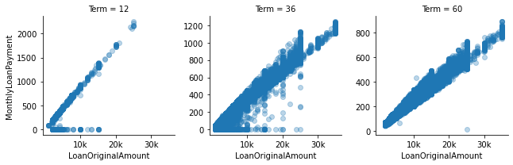

```python
# create faceted scatter plots on levels of the Term variable
g = sb.FacetGrid(data=df, col='Term', col_wrap = 4, height = 3, sharey=False)
g.map(plt.scatter, 'LoanOriginalAmount', 'MonthlyLoanPayment', alpha=0.3)

plt.xticks([10000, 20000, 30000], ['10k', '20k', '30k'])
plt.show()
```

In each of the faceted scatter plots, one can see how both the original loan amount disbursed varies with the monthly payment towards it. With increasing loan amounts, there seem to be upper outliers especially in the loan status and employment status with those with favorable statuses contributing higher amounts in a bid to service the loan quicker. Equally observed is a lack of contribution that provides the few lower outliers.

Let's better analyse this by looking at specific original loan amounts.

```python
# select loan amount of between $1000 and $5000
loans_low = (df['LoanOriginalAmount'] >= 1000) & (df['LoanOriginalAmount'] <= 5000 )
df_l = df.loc[loans_low,:]
```

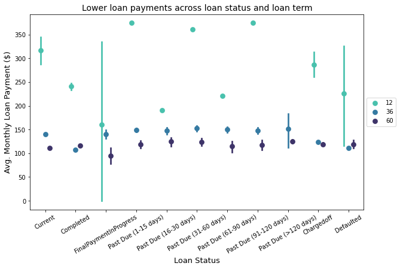

```python
plt.figure(figsize = [10,6])
sb.pointplot(data = df_l, x = 'LoanStatus', y = 'MonthlyLoanPayment', hue = 'Term', order=['Current', 'Completed', 'FinalPaymentInProgress', 'Past Due (1-15 days)', 'Past Due (16-30 days)',
                    'Past Due (31-60 days)', 'Past Due (61-90 days)', 'Past Due (91-120 days)', 'Past Due (>120 days)', 'Chargedoff', 'Defaulted'],
             palette = 'mako_r', linestyles="", dodge = 0.3)
plt.xticks(rotation = 30)
plt.title('Lower loan payments across loan status and loan term', size = 14)
plt.xlabel('Loan Status', size = 13)
plt.ylabel('Avg. Monthly Loan Payment ($)', size = 13)
plt.legend(loc = 6, bbox_to_anchor = (1.0, 0.5)) # legend to right of figure

plt.show();
```

We can see a decrease in mean monthly contributions across various loan terms as longer terms require less monthly payments. There are higher levels of uncertainity of payment as indicated by the errorbars for the 12-month loans in default, chargedoff or whose final payment is in progress. This shows unfavorable outcomes for borrowers in those categories and hence future preference for long-term loans.

```python
# select loan amount of between $10000 and $15000
loans_high = (df['LoanOriginalAmount'] >= 10000) & (df['LoanOriginalAmount'] <= 15000)
df_h = df.loc[loans_high,:]
```

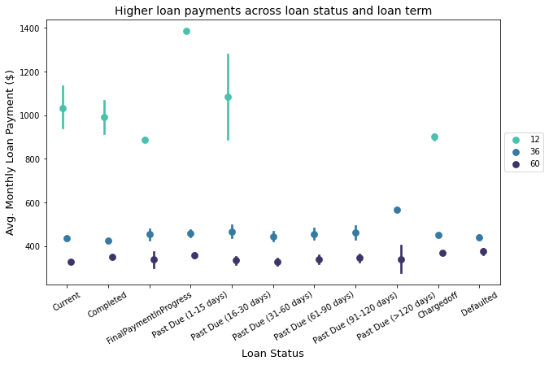

```python
plt.figure(figsize = [10,6])
sb.pointplot(data = df_h, x = 'LoanStatus', y = 'MonthlyLoanPayment', hue = 'Term', order=['Current', 'Completed', 'FinalPaymentInProgress', 'Past Due (1-15 days)', 'Past Due (16-30 days)',
                    'Past Due (31-60 days)', 'Past Due (61-90 days)', 'Past Due (91-120 days)', 'Past Due (>120 days)', 'Chargedoff', 'Defaulted'], palette = 'mako_r', linestyles = "", dodge = 0.2)
plt.xticks(rotation = 30)
plt.title('Higher loan payments across loan status and loan term', size = 14)
plt.xlabel('Loan Status', size = 13)
plt.ylabel('Avg. Monthly Loan Payment ($)', size =13)
plt.legend(loc = 6, bbox_to_anchor = (1.0, 0.5)) # legend to right of figure

plt.show();
```

The monthly loan payments still decrease the longer the loan term is. Borrowers who take on larger loans in short terms appear to have more uncertainity in paying off loan under the deliquent, currently servicing it and completed status. The 60-month term loans across all statuses is the most secure.

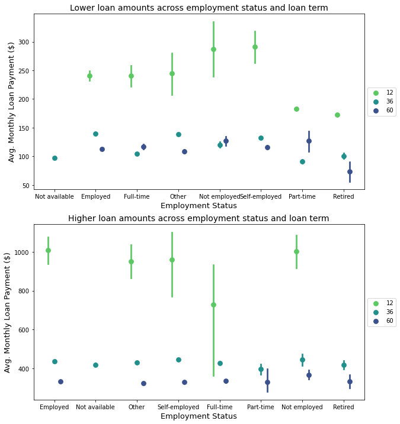

```python
plt.figure(figsize=[10, 12])

plt.subplot(2, 1, 1)
sb.pointplot(data = df_l, x = 'EmploymentStatus', y = 'MonthlyLoanPayment', hue = 'Term',
           palette = 'viridis_r', linestyles = '', dodge = 0.3)

plt.title('Lower loan amounts across employment status and loan term', size = 14)
plt.xlabel('Employment Status', size = 13)
plt.ylabel('Avg. Monthly Loan Payment ($)', size = 13)
plt.legend(loc = 6, bbox_to_anchor = (1.0, 0.5)) # legend to right of figure

plt.subplot(2, 1, 2)
sb.pointplot(data = df_h, x = 'EmploymentStatus', y = 'MonthlyLoanPayment', hue = 'Term',
           palette = 'viridis_r', linestyles = '', dodge = 0.3)

plt.title('Higher loan amounts across employment status and loan term', size = 14)
plt.xlabel('Employment Status', size = 13)
plt.ylabel('Avg. Monthly Loan Payment ($)', size = 13)
plt.legend(loc = 6, bbox_to_anchor = (1.0, 0.5)) # legend to right of figure

plt.show();
```

As confirmed, the short 12 month loan term has the highest level of uncertainity across both low and high loan amounts. Despite being employed, self-employed full time, contributing to that 12 month loan still has risk of servicing it. 60-month long term loans prove to have the lowest risk and favourable loan outcomes regardless of employment status.

#### Does the declared income range and if it is verifiable influence loan amounts?

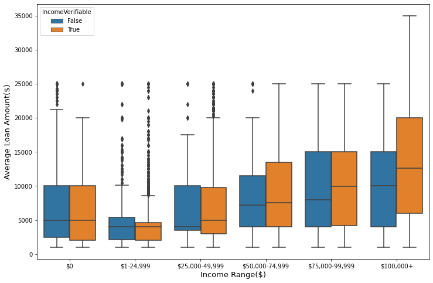

```python
plt.figure(figsize=[12, 8])
sb.boxplot(data=df, y='LoanOriginalAmount', x='IncomeRange', hue='IncomeVerifiable',
           order=['$0', '$1-24,999', '$25,000-49,999', '$50,000-74,999', '$75,000-99,999', '$100,000+'])

plt.xlabel('Income Range($)', size = 13)
plt.ylabel('Average Loan Amount($)',  size = 13)

plt.show()
```

To further expound on the previous results, the backing of documentation to prove ones income range for those that declared it results in more favourable loan outcomes compared to their counterparts who did not provide them. Though the median difference between the two is minor, the former appears to have a wider spread and even outliers which tells of a broader scope of money that can be loaned out.

#### For both borrowers and investors, how does the loan amount disbursed relate with the expected lender yield?

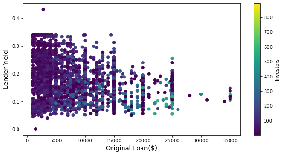

```python
# to ease visual plotting a sample of the loans were analysed
plt.figure(figsize=[10, 5])
plt.scatter(data = loan_sample, y = 'LenderYield', x ='LoanOriginalAmount', c = 'Investors')
plt.colorbar(label = 'Investors')

plt.xlabel('Original Loan($)', size = 13)
plt.ylabel('Lender Yield', size = 13)
plt.show()
```

This metric influences the lending as low lender yield with high number of investors affects the amount of money isssued as loans to borrowers with fewer borrowers getting huge loans.

### Talk about some of the relationships you observed in this part of the investigation. Were there features that strengthened each other in terms of looking at your feature(s) of interest?

For this investigation of the multivariate exploration, the strong positive relation between the loan amount and monthly payment towards it remained consistent across the categoric variables. This is especially true for borrowers with more favorable statuses as majority confidently qualified for loans they could afford within a regulated timeframe. Longer periods of 60 months seem most favorable for servicing a loan to completion. Higher and lower loan amounts have similar relationships in relation to the loan term but varies across the different statuses.Their monthly payments also have similar relations.

### Were there any interesting or surprising interactions between features?

It is not surprising that with the backing of documentation to verify ones income, loan outcomes were improved. However, not all income ranges had standard middle half ranges with majority having upper outliers beyond the whiskers to show favoarable loan amounts issued.

## Conclusions

- The primary focus was on the amount of money issued at the time of origination. This variable is heavily influenced by not only the borrowers' circumstances but the lender as well.Steps have been taken to explore major variables like the monthly loan payment with variables like the loan status amongst borrowers.
- A good lender does not have a stark contrast between the APR and interest rate as seen that would eventually make the loan expensive for borrowers.
- A history of having good standing regardless of the reason for applying for the loan greatly improves the loan outcome. As seen with debt consolidation being the top reason borrowers apply for loans, that will be of particular importance for future refinancing of other debts through loans.
- It is important to note that as much as investors can fund a loan, not every loan ends up being beneficial to the investor as some end up in default with those unable to pay and others are completely charged-off. This means that the loan is a liability and cannot benefit the investor.
- From the visualizations above, we can conclude that although the borrower's factors play the greatest role in determining the outcome of a loan, the kind of backing the lender has also influences how they structure the loan they offer.